# Regresión Bayesiana

Juan Barriola, Azul Villanueva y Franco Mastelli

15 de Octubre de 2022

```r
# Carga de librerías
library(tidyverse)
library(tidymodels)
library(brms)
library(GGally)
```

En esta notebook desarrollaremos modelos de regresión clásica y bayesiana para explicar/predecir los salarios de los jugadores de la NBA para la temporada 2022-2023 en base a información de la temporada pasada.

# Datasets

Trabajaremos con los datasets de salarios de la temporada 2022-2023 de la NBA y las estadísticas por partido de la temporada 2021-2022. La información se scrappeó de la página basketball-reference y la construcción estos datasets se encuentra en la notebook de construcción.

Cargamos los datasets y realizamos un join entre ambos mediante el nombre del jugador

```r
# Salarios 2022-2023
salarios_nba = read_csv("../Fuentes/nba/salarios_nba_2023.csv")
# Estadísticas por partido 2021-2022
estadisticas_por_partido_nba = read_csv("../Fuentes/nba/estadisticas_por_partido_nba_2022.csv") %>%
  # Conservamos el primer tipo de posicion declarada
  mutate(Pos = str_remove(string = Pos, pattern = "\\-.*"))
# Realizamos un join entre ambas tablas mediante el nombre
nba_salarios_estadisticas_partido = salarios_nba %>%
                            inner_join(y=estadisticas_por_partido_nba, on=jugador) %>%
                            drop_na()
# El dataset final queda
glimpse(nba_salarios_estadisticas_partido)
```

```
## Rows: 409
## Columns: 31
## $ jugador <chr> "Stephen Curry", "Russell Westbrook", "LeBron James", "Kevin D…
## $ equipo  <chr> "GSW", "LAL", "LAL", "BRK", "WAS", "POR", "MIL", "LAC", "GSW",…
## $ salario <dbl> 48070014, 47063478, 44474988, 44119845, 43279250, 42492492, 42…
## $ Pos     <chr> "PG", "PG", "PF", "PF", "SG", "PG", "PF", "PF", "SG", "C", "C"…
## $ Age     <dbl> 33, 33, 37, 33, 28, 31, 27, 31, 31, 29, 28, 30, 32, 29, 22, 23…
## $ Tm      <chr> "GSW", "LAL", "LAL", "BRK", "WAS", "POR", "MIL", "LAC", "GSW",…
## $ G       <dbl> 64, 78, 56, 55, 40, 29, 67, 31, 32, 66, 40, 66, 57, 73, 65, 76…
## $ GS      <dbl> 64, 78, 56, 55, 40, 29, 67, 31, 32, 66, 40, 66, 57, 73, 65, 76…
## $ MP      <dbl> 34.5, 34.3, 37.2, 37.2, 36.0, 36.4, 32.9, 34.7, 29.4, 32.1, 35…
## $ FG      <dbl> 8.4, 7.0, 11.4, 10.5, 8.7, 7.7, 10.3, 8.6, 7.7, 5.5, 9.3, 6.8,…
## $ FGA     <dbl> 19.1, 15.8, 21.8, 20.3, 19.3, 19.0, 18.6, 20.5, 17.9, 7.7, 17.…
## $ `FG%`   <dbl> 0.437, 0.444, 0.524, 0.518, 0.451, 0.402, 0.553, 0.421, 0.429,…
## $ `3P`    <dbl> 4.5, 1.0, 2.9, 2.1, 1.6, 3.2, 1.1, 2.9, 3.6, 0.0, 0.3, 2.5, 0.…
```

[output cut: 18 more lines]

```r
# Observemos los 10 jugadores con mayor salario
nba_salarios_estadisticas_partido %>% slice_max(order_by = salario, n=10)
```

| jugador | equipo | salario | Pos | Age | Tm | G | GS | MP | FG | FGA | FG% | 3P | 3PA | 3P% | 2P | 2PA | 2P% | eFG% | FT | FTA | FT% | ORB | DRB | TRB | AST | STL | BLK | TOV | PF | … |
| --- | --- | --- | --- | --- | --- | --- | --- | --- | --- | --- | --- | --- | --- | --- | --- | --- | --- | --- | --- | --- | --- | --- | --- | --- | --- | --- | --- | --- | --- | --- |
| Stephen Curry | GSW | 48070014 | PG | 33 | GSW | 64 | 64 | 34.5 | 8.4 | 19.1 | 0.437 | 4.5 | 11.7 | 0.380 | 3.9 | 7.4 | 0.527 | 0.554 | 4.3 | 4.7 | 0.923 | 0.5 | 4.7 | 5.2 | 6.3 | 1.3 | 0.4 | 3.2 | 2.0 | … |
| Russell Westbrook | LAL | 47063478 | PG | 33 | LAL | 78 | 78 | 34.3 | 7.0 | 15.8 | 0.444 | 1.0 | 3.4 | 0.298 | 6.0 | 12.4 | 0.485 | 0.476 | 3.4 | 5.1 | 0.667 | 1.4 | 6.0 | 7.4 | 7.1 | 1.0 | 0.3 | 3.8 | 3.0 | … |
| LeBron James | LAL | 44474988 | PF | 37 | LAL | 56 | 56 | 37.2 | 11.4 | 21.8 | 0.524 | 2.9 | 8.0 | 0.359 | 8.6 | 13.8 | 0.620 | 0.590 | 4.5 | 6.0 | 0.756 | 1.1 | 7.1 | 8.2 | 6.2 | 1.3 | 1.1 | 3.5 | 2.2 | … |
| Kevin Durant | BRK | 44119845 | PF | 33 | BRK | 55 | 55 | 37.2 | 10.5 | 20.3 | 0.518 | 2.1 | 5.5 | 0.383 | 8.4 | 14.8 | 0.568 | 0.570 | 6.8 | 7.4 | 0.910 | 0.5 | 6.9 | 7.4 | 6.4 | 0.9 | 0.9 | 3.5 | 2.1 | … |
| Bradley Beal | WAS | 43279250 | SG | 28 | WAS | 40 | 40 | 36.0 | 8.7 | 19.3 | 0.451 | 1.6 | 5.3 | 0.300 | 7.1 | 14.0 | 0.508 | 0.492 | 4.2 | 5.1 | 0.833 | 1.0 | 3.8 | 4.7 | 6.6 | 0.9 | 0.4 | 3.4 | 2.4 | … |
| Damian Lillard | POR | 42492492 | PG | 31 | POR | 29 | 29 | 36.4 | 7.7 | 19.0 | 0.402 | 3.2 | 9.8 | 0.324 | 4.5 | 9.2 | 0.485 | 0.486 | 5.5 | 6.2 | 0.878 | 0.4 | 3.7 | 4.1 | 7.3 | 0.6 | 0.4 | 2.9 | 1.3 | … |
| Giannis Antetokounmpo | MIL | 42492492 | PF | 27 | MIL | 67 | 67 | 32.9 | 10.3 | 18.6 | 0.553 | 1.1 | 3.6 | 0.293 | 9.2 | 15.0 | 0.616 | 0.582 | 8.3 | 11.4 | 0.722 | 2.0 | 9.6 | 11.6 | 5.8 | 1.1 | 1.4 | 3.3 | 3.2 | … |
| Paul George | LAC | 42492492 | PF | 31 | LAC | 31 | 31 | 34.7 | 8.6 | 20.5 | 0.421 | 2.9 | 8.3 | 0.354 | 5.7 | 12.2 | 0.467 | 0.493 | 4.1 | 4.8 | 0.858 | 0.4 | 6.5 | 6.9 | 5.7 | 2.2 | 0.4 | 4.1 | 2.4 | … |
| Klay Thompson | GSW | 40600080 | SG | 31 | GSW | 32 | 32 | 29.4 | 7.7 | 17.9 | 0.429 | 3.6 | 9.3 | 0.385 | 4.1 | 8.7 | 0.477 | 0.529 | 1.4 | 1.6 | 0.902 | 0.5 | 3.4 | 3.9 | 2.8 | 0.5 | 0.5 | 1.3 | 1.7 | … |
| Rudy Gobert | MIN | 38172414 | C | 29 | UTA | 66 | 66 | 32.1 | 5.5 | 7.7 | 0.713 | 0.0 | 0.1 | 0.000 | 5.5 | 7.6 | 0.718 | 0.713 | 4.6 | 6.7 | 0.690 | 3.7 | 11.0 | 14.7 | 1.1 | 0.7 | 2.1 | 1.8 | 2.7 | … |

# Analisis exploratorios

Como se mencionó previamente, nuestro interés está en explicar la variable del salario anual. Usaremos pocas variables para mantener los modelos sencillos:

**Variable dependiente**

- salario: salario anual de la temporada 2022-23

**Variables independientes**

- PTS: puntos por partido en la temporada 2021-22
- Age: edad en años del jugador en la temporada 2021-22
- TRB: rebotes totales (ofensivos y defensivos) por partido en la temporada 2021-22

Realizamos primero un correlagrama entre las 4 variables numéricas

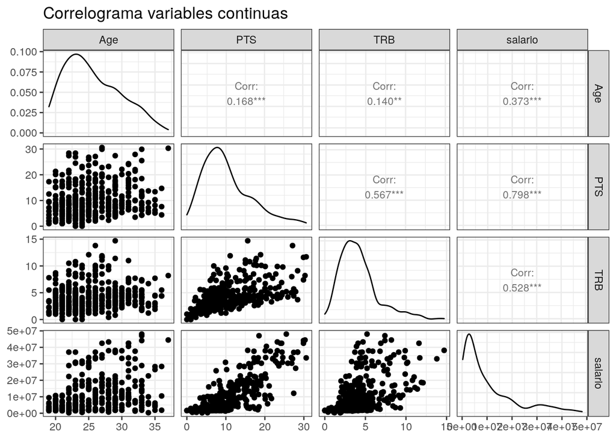

```r
nba_salarios_estadisticas_partido %>%
  select(Age, PTS, TRB, salario) %>%
  ggpairs(upper = list(continuous = wrap("cor", size = 3, hjust=0.5)), progress=FALSE) +
  theme(axis.text.x = element_text(angle = 90, hjust = 1), legend.position = "bottom") +
  theme_bw() +
  labs(title='Correlograma variables continuas')
```

Observamos:

- Todas las variables presentan asimetría positica. Se destaca la distribución del salario con una asimetrìa muy fuerte
- Las tres variables presentan una correlación positiva con el salario. Los puntos por partido presentan una correlación fuerte (0.798) mientras que los rebotes totales por partido y la edad presentan valores de correlación más moderados

# Modelo lineal clásico

Recordemos que el enfoque clásico postula parámetros fijos y desconocidos y un target aleatorio

$Y \sim N(\beta_0+\sum\limits_{i=1}^p{\beta_iX_i} , \sigma)$

Siendo $\beta_0, \beta_1,..., \beta_p, \sigma$ los parámetros fijos y desconocidos que debemos estimar.

## Modelo simple

Realicemos un modelo de regresión simple para predecir el salario en función de los puntos por partido:

$Salario = \beta_0 + \beta_1 Puntos + \varepsilon$

En este caso vamos a estimar tres parámetros

```r
# Fiteamos el modelo
modelo_clasico_puntos = lm(data = nba_salarios_estadisticas_partido, formula = salario ~ PTS)
```

Observamos los valores de los coeficientes estimados junto con el p-valor del test de significatividad individual y los límites de los intervalos de confianza al 95%

```r
# Observamos los valores de los coeficientes estimados
coef_modelo_clasico_puntos = tidy(modelo_clasico_puntos, conf.int = TRUE, conf.level = 0.95)
coef_modelo_clasico_puntos
```

| term | estimate | std.error | statistic | p.value | conf.low | conf.high |
| --- | --- | --- | --- | --- | --- | --- |
| (Intercept) | -3866610 | 607626.66 | -6.363463 | 5.318865e-10 | -5061088 | -2672131 |
| PTS | 1338924 | 50074.14 | 26.738835 | 1.190614e-91 | 1240488 | 1437361 |

El valor de $\hat{\beta_1}$ indica que por cada punto por partido adicional el salario esperado aumenta en 1338924 dólares.

El límite inferior del intervalo es 1240488 y el superior 1437361

Observamos los valores de sigma y el p-valor del test de significatividad global

```r
# Observamos los valores de la evaluación global
glance(modelo_clasico_puntos)
```

| r.squared | adj.r.squared | sigma | statistic | p.value | df | logLik | AIC | BIC | deviance | df.residual | nobs |
| --- | --- | --- | --- | --- | --- | --- | --- | --- | --- | --- | --- |
| 0.6372437 | 0.6363524 | 6407267 | 714.9653 | 1.190614e-91 | 1 | -6989.577 | 13985.15 | 13997.2 | 1.67086e+16 | 407 | 409 |

## Modelo múltiple

Realicemos un modelo de regresión múltiple para predecir el salario en función de los puntos por partido, edad y rebotes totales por partido:

$Salario = \beta_0 + \beta_1 Puntos + \beta_2 Edad + \beta_3 RebotesTotales+ \varepsilon$

En este caso vamos a estimar cinco parámetros

```r
# Fiteamos el modelo
modelo_clasico_multiple = lm(data = nba_salarios_estadisticas_partido, formula = salario ~ PTS + Age + TRB)
```

Observamos los valores de los coeficientes estimados junto con el p-valor del test de significatividad individual y los límites de los intervalos de confianza al 95%

```r
# Observamos los valores de los coeficientes estimados
coef_modelo_clasico_multiple = tidy(modelo_clasico_multiple, conf.int = TRUE)
coef_modelo_clasico_multiple
```

| term | estimate | std.error | statistic | p.value | conf.low | conf.high |
| --- | --- | --- | --- | --- | --- | --- |
| (Intercept) | -19609602.0 | 1799604.14 | -10.896620 | 2.022851e-24 | -23147333.4 | -16071870.5 |
| PTS | 1180222.1 | 55554.22 | 21.244507 | 7.690727e-68 | 1071011.5 | 1289432.7 |
| Age | 610324.0 | 69718.17 | 8.754159 | 5.633869e-17 | 473269.3 | 747378.7 |
| TRB | 421751.9 | 145954.28 | 2.889616 | 4.064455e-03 | 134829.3 | 708674.4 |

Observamos los valores de sigma y el p-valor del test de significatividad global

```r
# Observamos los valores de la evaluación global
glance(modelo_clasico_multiple)
```

| r.squared | adj.r.squared | sigma | statistic | p.value | df | logLik | AIC | BIC | deviance | df.residual | nobs |
| --- | --- | --- | --- | --- | --- | --- | --- | --- | --- | --- | --- |
| 0.702007 | 0.6997996 | 5821542 | 318.0307 | 4.537653e-106 | 3 | -6949.36 | 13908.72 | 13928.79 | 1.372559e+16 | 405 | 409 |

# Modelo Bayesiano

Recordemos que el enfoque bayesiano postula parámetros aleatorios para el mismo modelo:

$Y \sim N(\beta_0+\sum\limits_{i=1}^p{\beta_iX_i} , \sigma)$

Donde:

$\beta_0 \sim N(0,\tau_{\beta_0})$

$\beta_i \sim N(0,\tau_{\beta_i})$ para i entre 1 y p

$\sigma \sim Exp(\lambda)$

Siendo $\tau_{\beta_0}, \tau_{\beta_i}, \lambda$ fijos y propuestos por nosotros

## Paquete brms

Vamos a utilizar la implementación de modelos bayesianos de la librería **brms** (Bayesian Regression Models using Stan). El paper de esta librería se puede encontrar [aquí](https://cran.r-project.org/web/packages/brms/vignettes/brms_overview.pdf)

La función que vamos a utilizar es `brm()` la cual permite construir una gran variedad de modelos bayesianos. Algunos de sus parámetros más relevantes son:

**Modelo**

- `formula`: la fórmula del modelo que queremos realizar
- `data`: dataset a utilizar
- `family`: distribución de la variable respuesta/target y función link. Por default se aplica la distribución gaussiana/normal
- `prior`: distribuciones prior de los parámetros

**Simulación**

- `init`: valores iniciales para el muestreo de los parámetros. Por default es random
- `chains`: cantidad de cadenas de Markov. Por default son 4
- `iter`: cantidad de iteraciones totales por cadena incluyendo warmup. Por default son 2000
- `warmup`: cantidad de iteraciones de warmup. Por default es iter/2

**Ejecución**

- `cores`: cantidad de núcleos a utilizar en la ejecución de las cadenas de manera paralelizada. Por default es 1.
- `seed`: semilla para reproducibilidad

## Modelo simple

Realicemos el mismo modelo simple con la configuración default de brms:

$Salario \sim N(\beta_0+\beta_1Puntos, \sigma)$

```r
regresion_bayesiana_simple <- brm(
  formula = salario ~ PTS,
  data = nba_salarios_estadisticas_partido,
  cores = 6,
  seed = 1992
)
```

### Summary

Observemos un resumen del modelo usando la función `summary`

```r
# Vemos el resumen del modelo
summary(regresion_bayesiana_simple)
```

```
##  Family: gaussian
##   Links: mu = identity; sigma = identity
## Formula: salario ~ PTS
##    Data: nba_salarios_estadisticas_partido (Number of observations: 409)
##   Draws: 4 chains, each with iter = 2000; warmup = 1000; thin = 1;
##          total post-warmup draws = 4000
##
## Population-Level Effects:
##              Estimate Est.Error    l-95% CI    u-95% CI Rhat Bulk_ESS Tail_ESS
## Intercept -3868554.03 600575.19 -5030588.92 -2734003.09 1.00     3975     2987
## PTS        1337877.27  49983.32  1241681.62  1435855.55 1.00     3764     3138
##
## Family Specific Parameters:
##         Estimate Est.Error   l-95% CI   u-95% CI Rhat Bulk_ESS Tail_ESS
## sigma 6425596.60 228160.60 5996099.56 6887778.09 1.00     4584     3054
##
## Draws were sampled using sampling(NUTS). For each parameter, Bulk_ESS
## and Tail_ESS are effective sample size measures, and Rhat is the potential
## scale reduction factor on split chains (at convergence, Rhat = 1).
```

#### Configuración del modelo

Lo primero que se observa es la configuración del modelo:

- La **familia** es gaussiana y las **funciones de link** para los parámetros $\mu$ y $\sigma$ son la función identidad
- La fórmula y dataset que definimos
- La configuración para el muestreo (draws) para el proceso de MCMC:
  - Hay 4 **cadenas**
  - Son 2000 **iteraciones** de las cuales 1000 son de **warmup** (por cadena)
  - En total son 4 cadenas cada una con 2000 iteraciones en total, dando un total de 8000 iteraciones. Como la mitad son iteraciones de warmup el **total de muestreos (draws) post warmup** es 4000.

#### Parámetros

Luego podemos ver información de los parámetros de la población y de los parámetros especificos de la familia:

- **Estimate** es el promedio de la distribución a posteriori
- **Est. Error** es el desvío estándar de la distribución a posteriori
- **l-95% CI** y **u-95% CI** son el límite inferior y superior del intervalo de credibilidad de 95% a dos colas (Credible intervals) basados en los cuantiles de la distribución a posteriori. Esto quiere decir que el límite inferior es el cuantil 2.5 y el superior el 97.5
- **Rhat** brinda información sobre la convergencia del algoritmo para cada parámetro. Si es mayor a 1, las cadenas no han convergido y es recomendable sumar más iteraciones y/o modificar las priors.

Si accedemos al elemento `fit` del modelo obtenemos algunos datos adicionales

```r
# Accedemos al fit del modelo
regresion_bayesiana_simple$fit
```

```
## Inference for Stan model: 52bd4c44b5b8c6574d9a3feffcf77c5a.
## 4 chains, each with iter=2000; warmup=1000; thin=1;
## post-warmup draws per chain=1000, total post-warmup draws=4000.
##
##                    mean se_mean        sd        2.5%         25%         50%
## b_Intercept -3868554.03 9531.70 600575.19 -5030588.92 -4271674.28 -3849892.68
## b_PTS        1337877.27  818.33  49983.32  1241681.62  1303383.16  1337726.56
## sigma        6425596.60 3396.04 228160.60  5996099.56  6261833.89  6416735.25
## lprior           -33.47    0.00      0.06      -33.60      -33.51      -33.47
## lp__           -7008.88    0.03      1.22    -7012.01    -7009.46    -7008.57
##                     75%       97.5% n_eff Rhat
## b_Intercept -3465294.20 -2734003.09  3970    1
## b_PTS        1371605.15  1435855.55  3731    1
## sigma        6580684.10  6887778.09  4514    1
## lprior           -33.43      -33.35  4523    1
## lp__           -7007.97    -7007.48  2163    1
##
## Samples were drawn using NUTS(diag_e) at Sat Oct 15 10:02:12 2022.
## For each parameter, n_eff is a crude measure of effective sample size,
## and Rhat is the potential scale reduction factor on split chains (at
## convergence, Rhat=1).
```

Vemos que se reporta el error estándar de la media y otros cuantiles de la distribución a posteriori de los parámetros

#### Gráficos

Con el comando `plot` podemos observar la distribución a posteriori y el proceso de muestreo de las cadenas de cada parámetro.

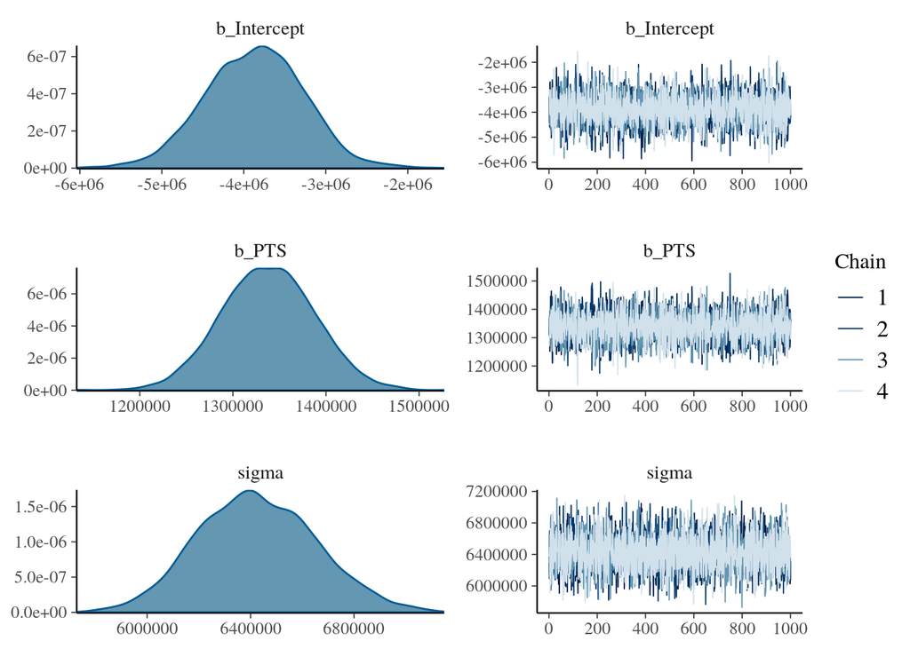

```r
# Realizamos el gráfico con plot
plot(regresion_bayesiana_simple)
```

## Tidybayes

Tidybayes es una librería que adapta el enfoque de tidyverse para trabajar con los modelos bayesianos de las librerías más comunes en R (aunque no forma parte de tidyverse). Un resumen de esta librería y sus funcionalidades principales se encuentra [aquí](http://mjskay.github.io/tidybayes/)

```r
library(tidybayes)
```

### Acceso a la información

En primer lugar siempre es útil usar la función `get_variables` para obtener las variables de nuestro modelo

```r
get_variables(regresion_bayesiana_simple)
```

```
##  [1] "b_Intercept"   "b_PTS"         "sigma"         "lprior"
##  [5] "lp__"          "accept_stat__" "stepsize__"    "treedepth__"
##  [9] "n_leapfrog__"  "divergent__"   "energy__"
```

Dos funciones muy útiles son `spread_draws` y `gather_draws`. En ambas hay que seleccionar cuáles son las variables que queremos analizar; la primera nos devolvera la información sobre el proceso de muestreo en **formato wide** y la segunda en **formato long**.

Vamos a obtener el valor de las variables seleccionadas en cada una de las iteraciones post-warmup para cada cadena

```r
# Usando la funcion spread_draws
regresion_bayesiana_simple %>%
  spread_draws(b_Intercept, b_PTS, sigma) %>%
  filter(.iteration <= 10)
```

| .chain | .iteration | .draw | b_Intercept | b_PTS | sigma |
| --- | --- | --- | --- | --- | --- |
| 1 | 1 | 1 | -3329512 | 1352990 | 6296624 |
| 1 | 2 | 2 | -3347934 | 1312603 | 6092660 |
| 1 | 3 | 3 | -4590347 | 1376741 | 6700017 |
| 1 | 4 | 4 | -2822866 | 1251869 | 6446959 |
| 1 | 5 | 5 | -2788865 | 1277236 | 6514389 |
| 1 | 6 | 6 | -3798232 | 1343941 | 6724707 |
| 1 | 7 | 7 | -4675076 | 1446162 | 6648844 |
| 1 | 8 | 8 | -3650260 | 1329354 | 6566526 |
| 1 | 9 | 9 | -4233852 | 1363853 | 6233966 |
| 1 | 10 | 10 | -5024962 | 1464451 | 6266037 |

[output cut: 30 more lines]

```r
# Usando la funcion gather_draws
regresion_bayesiana_simple %>%
  gather_draws(b_Intercept, b_PTS, sigma) %>%
  filter(.iteration <= 10)
```

| .chain | .iteration | .draw | .variable | .value |
| --- | --- | --- | --- | --- |
| 1 | 1 | 1 | b_Intercept | -3329512 |
| 1 | 2 | 2 | b_Intercept | -3347934 |
| 1 | 3 | 3 | b_Intercept | -4590347 |
| 1 | 4 | 4 | b_Intercept | -2822866 |
| 1 | 5 | 5 | b_Intercept | -2788865 |
| 1 | 6 | 6 | b_Intercept | -3798232 |
| 1 | 7 | 7 | b_Intercept | -4675076 |
| 1 | 8 | 8 | b_Intercept | -3650260 |
| 1 | 9 | 9 | b_Intercept | -4233852 |
| 1 | 10 | 10 | b_Intercept | -5024962 |

[output cut: 110 more lines]

### Resumen distribución a posteriori

Existe una gran cantidad de funciones para obtener estadísticos de resumen de las distribuciones a posteriori de los parámetros.

Se pueden calcular estadísticos como la media, mediana y moda para distintos tipos de intervalos:

- **Intervalo de Cuantil** (Quantile Interval): es el intervalo en el que la probabilidad de estar por encima y por debajo son la misma
- **Intervalo de Mayor Densidad** (Highest Density Interval): es el intervalo más angosto o corto que concentra un determinado nivel de probabilidad

Por ejemplo, podemos calcular la media de nuestros tres parámetros usando el intervalo de cuantil con la función `mean_qi` y con el intervalo de mayor densidad usando la función `mean_hdi`

```r
# Calculamos la media según el intervalo de cuantil
media_qi = regresion_bayesiana_simple %>%
  gather_draws(b_Intercept, b_PTS, sigma) %>%
  mean_qi()

# Calculamos la media según el intervalo de mayor densidad
media_hdi = regresion_bayesiana_simple %>%
  gather_draws(b_Intercept, b_PTS, sigma) %>%
  mean_hdi()

# Combinamos ambos resultados
bind_rows(media_qi, media_hdi) %>% arrange(.variable)
```

| .variable | .value | .lower | .upper | .width | .point | .interval |
| --- | --- | --- | --- | --- | --- | --- |
| b_Intercept | -3868554 | -5030589 | -2734003 | 0.95 | mean | qi |
| b_Intercept | -3868554 | -5030708 | -2734053 | 0.95 | mean | hdi |
| b_PTS | 1337877 | 1241682 | 1435856 | 0.95 | mean | qi |
| b_PTS | 1337877 | 1238618 | 1431683 | 0.95 | mean | hdi |
| sigma | 6425597 | 5996100 | 6887778 | 0.95 | mean | qi |
| sigma | 6425597 | 6007680 | 6893296 | 0.95 | mean | hdi |

La función `summarise_draws` permite obtener una gran cantidad de información de la distribución a posteriori. Por default utiliza el método de intervalo por cuantiles.

```r
# Resumen general de las distribuciones a posteriori
regresion_bayesiana_simple %>%
  spread_draws(b_Intercept, b_PTS, sigma) %>%
  summarise_draws()
```

| variable | mean | median | sd | mad | q5 | q95 | rhat | ess_bulk | ess_tail |
| --- | --- | --- | --- | --- | --- | --- | --- | --- | --- |
| b_Intercept | -3868554 | -3849893 | 600575.19 | 601100.04 | -4863449 | -2922442 | 0.9998739 | 3975.210 | 2986.848 |
| b_PTS | 1337877 | 1337727 | 49983.32 | 50590.24 | 1256605 | 1419764 | 0.9997398 | 3764.257 | 3138.210 |
| sigma | 6425597 | 6416735 | 228160.60 | 235574.03 | 6062546 | 6814494 | 1.0022623 | 4583.691 | 3054.048 |

## Modelo simple: Priors

Los modelos bayesianos requieren que se establezcan distribuciones priors para cada uno de los parámetros. Las mismas pueden ser no informativas o representar supuestos fuertes sobre los datos.

Veamos las priors de nuestro modelo de regresión bayesiana simple con la función `prior_summary` de **brms**

```r
# Observamos las priors por default
prior_summary(regresion_bayesiana_simple)
```

| prior | class | coef | group | resp | dpar | nlpar | lb | ub | source |
| --- | --- | --- | --- | --- | --- | --- | --- | --- | --- |
|  | b |  |  |  |  |  |  |  | default |
|  | b | PTS |  |  |  |  |  |  | default |
| student_t(3, 5739840, 5787699.8) | Intercept |  |  |  |  |  |  |  | default |
| student_t(3, 0, 5787699.8) | sigma |  |  |  |  |  | 0 |  | default |

En este caso observamos que usa por default una distribución t de Student para el intercepto y el desvío estándar. El parámetro asociado a la variable de puntos por partido tiene una prior plana (no informativa).

Para definir priors vamos a utilizar el argumento **prior** dentro de la función `brm`. La lista de distribuciones priors que podemos utilizar es muy extensa y se pueden revisar en la documentación de Stan: [distribuciones discretas](https://mc-stan.org/docs/functions-reference/discrete-distributions.html#discrete-distributions) y [distribuciones continuas](https://mc-stan.org/docs/functions-reference/continuous-distributions.html#continuous-distributions)

Para ejemplificar el impacto de las priors comparemos los resultados de especificar una distribución prior “adecuada” y otra “inadecuada”. En ambos casos vamos a estar usando una distribución normal.

Para la distribución prior “adecuada” vamos a plantear $\beta_1 \sim N(1000000, 250000)$

```r
regresion_bayesiana_simple_prior_adecuada <- brm(
  formula = salario ~ PTS,
  data = nba_salarios_estadisticas_partido,
  prior = prior(normal(1000000, 250000), coef = PTS),
  cores = 6,
  seed = 1992
)
```

Para la distribución prior “inadecuada” vamos a plantear $\beta_1 \sim N(-1000000, 100000)$

```r
regresion_bayesiana_simple_prior_inadecuada <- brm(
  formula = salario ~ PTS,
  data = nba_salarios_estadisticas_partido,
  prior = prior(normal(-1000000, 100000), coef = PTS),
  cores = 6,
  seed = 1992
)
```

Observemos las priors en ambos casos:

```r
# Observamos las priors del modelo adecuado
prior_summary(regresion_bayesiana_simple_prior_adecuada)
```

| prior | class | coef | group | resp | dpar | nlpar | lb | ub | source |
| --- | --- | --- | --- | --- | --- | --- | --- | --- | --- |
|  | b |  |  |  |  |  |  |  | default |
| normal(1e+06, 250000) | b | PTS |  |  |  |  |  |  | user |
| student_t(3, 5739840, 5787699.8) | Intercept |  |  |  |  |  |  |  | default |
| student_t(3, 0, 5787699.8) | sigma |  |  |  |  |  | 0 |  | default |

```r
# Observamos las priors del modelo adecuado
prior_summary(regresion_bayesiana_simple_prior_inadecuada)
```

| prior | class | coef | group | resp | dpar | nlpar | lb | ub | source |
| --- | --- | --- | --- | --- | --- | --- | --- | --- | --- |
|  | b |  |  |  |  |  |  |  | default |
| normal(-1e+06, 1e+05) | b | PTS |  |  |  |  |  |  | user |
| student_t(3, 5739840, 5787699.8) | Intercept |  |  |  |  |  |  |  | default |
| student_t(3, 0, 5787699.8) | sigma |  |  |  |  |  | 0 |  | default |

Veamos el resumen de las distribuciones a posteriori para ambos casos

```r
# Resumen general de las distribuciones a posteriori
regresion_bayesiana_simple_prior_adecuada %>%
  spread_draws(b_Intercept, b_PTS, sigma) %>%
  summarise_draws()
```

| variable | mean | median | sd | mad | q5 | q95 | rhat | ess_bulk | ess_tail |
| --- | --- | --- | --- | --- | --- | --- | --- | --- | --- |
| b_Intercept | -3753527 | -3749715 | 599282.11 | 582551.52 | -4735342 | -2787002 | 1.000165 | 3640.321 | 2612.722 |
| b_PTS | 1325436 | 1324912 | 48914.15 | 48986.65 | 1246443 | 1404912 | 1.000485 | 3730.575 | 3003.400 |
| sigma | 6419685 | 6406990 | 227674.29 | 225353.04 | 6059912 | 6810010 | 1.000273 | 3483.233 | 2392.725 |

Para el caso de la prior “adecuada” obtenemos una distribución a posteriori muy similar a la que teníamos con la prior no informativa

```r
# Resumen general de las distribuciones a posteriori
regresion_bayesiana_simple_prior_inadecuada %>%
  spread_draws(b_Intercept, b_PTS, sigma) %>%
  summarise_draws()
```

| variable | mean | median | sd | mad | q5 | q95 | rhat | ess_bulk | ess_tail |
| --- | --- | --- | --- | --- | --- | --- | --- | --- | --- |
| b_Intercept | 2200997.8 | 2201359.9 | 729431.92 | 744382.53 | 1025668.0 | 3415890 | 1.002266 | 2741.720 | 2750.630 |
| b_PTS | 751032.3 | 751273.4 | 61949.94 | 63180.94 | 648676.9 | 853834 | 1.000030 | 2616.158 | 2776.684 |
| sigma | 7418147.4 | 7407811.1 | 323567.94 | 326227.68 | 6906547.2 | 7973188 | 1.001926 | 2311.521 | 2440.706 |

En el caso de la prior inadecuada vemos que la media de la distribución a posteriori de $\beta_1$ es positiva y tiene un valor de 751032 a pesar que habíamos postulado una media negativa y un desvío “pequeño” . Sin embargo, observamos cambios importantes no solo en la distribución a posteriori del parámetro $\beta_1$ sino también para $\beta_0$ y $\sigma$.

Veamos gráficamente la comparación de las distribuciones a posteriori de los parámetros entre los modelos de distintas priors:

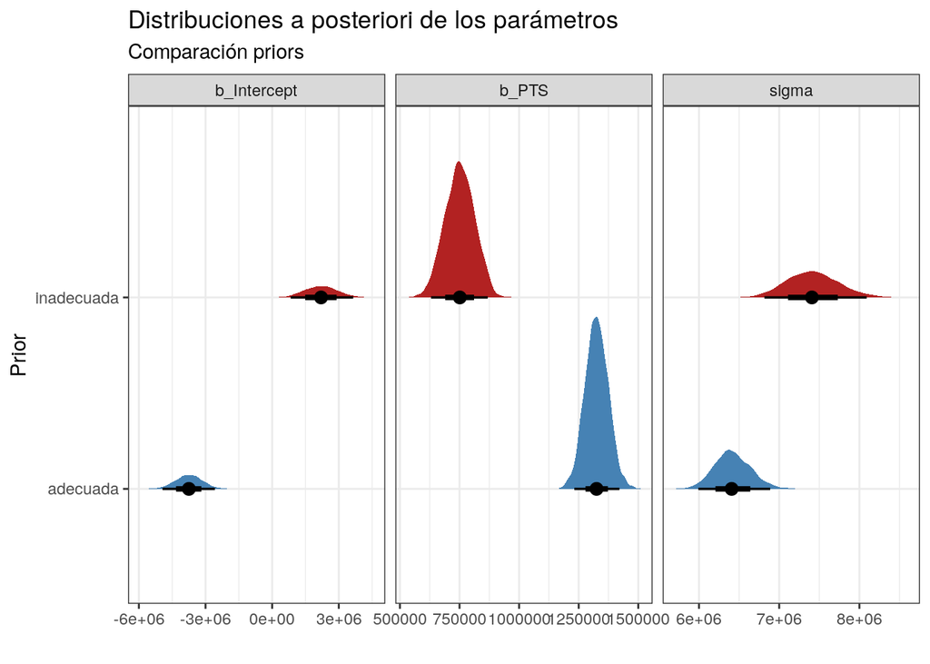

```r
# Obtenemos las draws del modelo con prior adecuada
draws_prior_adecuada = regresion_bayesiana_simple_prior_adecuada %>%
                          gather_draws(b_Intercept, b_PTS, sigma) %>%
                          ungroup() %>%
                          transmute(prior = 'adecuada',
                                    parametro = .variable,
                                    valor = .value)

# Obtenemos las draws del modelo con prior inadecuada
draws_prior_inadecuada = regresion_bayesiana_simple_prior_inadecuada %>%
                          gather_draws(b_Intercept, b_PTS, sigma) %>%
                          ungroup() %>%
                          transmute(prior = 'inadecuada',
                                    parametro = .variable,
                                    valor = .value)
# Concatenamos ambos dataframes
comparacion_draws = bind_rows(draws_prior_adecuada, draws_prior_inadecuada)

# Gráfico de ambas distribuciones
ggplot(data=comparacion_draws, aes(x = valor, y = prior, fill=prior)) +
  stat_halfeye() +
  facet_wrap(~parametro, scales = "free_x", )+
  labs(title = "Distribuciones a posteriori de los parámetros", subtitle = "Comparación priors", x="", y="Prior") +
  scale_fill_manual(values=c("steelblue","firebrick"), guide="none") +
  theme_bw()
```

## Modelo multiple

Realicemos un modelo múltiple con la configuración default usando las variables PTS, Age y TRB como predictoras del salario

```r
regresion_bayesiana_multiple <- brm(
  formula = salario ~ PTS + Age + TRB,
  data = nba_salarios_estadisticas_partido,
  cores = 6,
  seed = 1992
)
```

Observemos un resumen del modelo usando la función `summary`

```r
summary(regresion_bayesiana_multiple)
```

```
##  Family: gaussian
##   Links: mu = identity; sigma = identity
## Formula: salario ~ PTS + Age + TRB
##    Data: nba_salarios_estadisticas_partido (Number of observations: 409)
##   Draws: 4 chains, each with iter = 2000; warmup = 1000; thin = 1;
##          total post-warmup draws = 4000
##
## Population-Level Effects:
##               Estimate  Est.Error     l-95% CI     u-95% CI Rhat Bulk_ESS
## Intercept -19590911.28 1788970.68 -23088338.87 -16083891.10 1.00     5119
## PTS         1180137.17   57869.96   1066076.73   1292647.75 1.00     4246
## Age          609096.42   69278.43    475946.54    743568.63 1.00     4828
## TRB          422199.97  148572.93    132321.95    711440.40 1.00     4047
##           Tail_ESS
## Intercept     3162
## PTS           3061
## Age           2687
## TRB           2877
##
## Family Specific Parameters:
##         Estimate Est.Error   l-95% CI   u-95% CI Rhat Bulk_ESS Tail_ESS
## sigma 5832845.17 206359.82 5449507.50 6254413.82 1.00     4697     2799
##
## Draws were sampled using sampling(NUTS). For each parameter, Bulk_ESS
## and Tail_ESS are effective sample size measures, and Rhat is the potential
## scale reduction factor on split chains (at convergence, Rhat = 1).
```

Con el stat `stat_halfeye` de **tidybayes** podemos realizar un gráfico de las distribuciones a posteriori de los parámetros de interés.

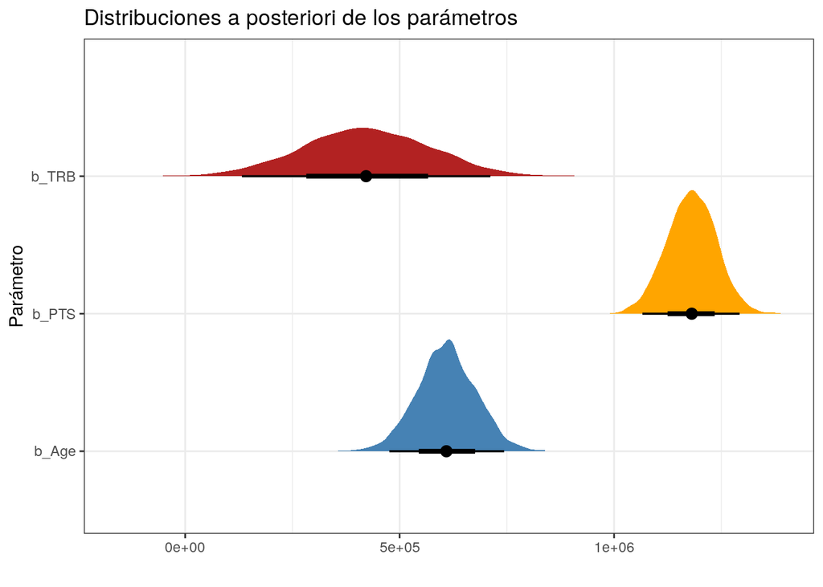

```r
# Realizamos el gràfico de las distribuciones a posteriori de los parámetros
regresion_bayesiana_multiple %>%
  gather_draws(b_PTS, b_Age, b_TRB) %>%
  ggplot(aes(x = .value, y = .variable, fill=.variable)) +
  stat_halfeye() +
  labs(title = "Distribuciones a posteriori de los parámetros", x="", y="Parámetro") +
  scale_fill_manual(values=c("steelblue", "orange", "firebrick") ,guide="none") +
  theme_bw()
```

También podemos comparar los resultados de la estimación puntual y los intervalos de la distribución a posteriori de los parámetros del modelo bayesiano vs la estimación e intervalos de confianza del modelo lineal clásico. Con la función `to_broom_names` de **tidybayes** podemos tener rápidamente nombres de columna idénticos a los que nos brinda el comando `tidy` de **broom**

```r
# Construimos el dataset de estimacion del modelo bayesiano
tidy_bayesiano_multiple = regresion_bayesiana_multiple %>%
  gather_draws(b_PTS, b_Age, b_TRB) %>%
  mean_qi() %>%
  to_broom_names() %>%
  mutate(term = str_remove(term, "b_"),
         modelo = "bayesiano")
tidy_bayesiano_multiple
```

| term | estimate | conf.low | conf.high | .width | .point | .interval | modelo |
| --- | --- | --- | --- | --- | --- | --- | --- |
| Age | 609096.4 | 475946.5 | 743568.6 | 0.95 | mean | qi | bayesiano |
| PTS | 1180137.2 | 1066076.7 | 1292647.8 | 0.95 | mean | qi | bayesiano |
| TRB | 422200.0 | 132321.9 | 711440.4 | 0.95 | mean | qi | bayesiano |

```r
# Emprolijamos el dataset de estimacionn del modelo clásico
tidy_clasico_multiple = coef_modelo_clasico_multiple %>%
                          filter(term!="(Intercept)") %>%
                          mutate(modelo="clasico")
tidy_clasico_multiple
```

| term | estimate | std.error | statistic | p.value | conf.low | conf.high | modelo |
| --- | --- | --- | --- | --- | --- | --- | --- |
| PTS | 1180222.1 | 55554.22 | 21.244507 | 7.690727e-68 | 1071011.5 | 1289432.7 | clasico |
| Age | 610324.0 | 69718.17 | 8.754159 | 5.633869e-17 | 473269.3 | 747378.7 | clasico |
| TRB | 421751.9 | 145954.28 | 2.889616 | 4.064455e-03 | 134829.3 | 708674.4 | clasico |

Concatenamos ambos datasets y seleccionamos las columnas de la estimación y los límites del intervalo de confianza

```r
bind_rows(tidy_clasico_multiple, tidy_bayesiano_multiple) %>%
  select(modelo, term, estimate, conf.low, conf.high) %>%
  arrange(term)
```

| modelo | term | estimate | conf.low | conf.high |
| --- | --- | --- | --- | --- |
| clasico | Age | 610324.0 | 473269.3 | 747378.7 |
| bayesiano | Age | 609096.4 | 475946.5 | 743568.6 |
| clasico | PTS | 1180222.1 | 1071011.5 | 1289432.7 |
| bayesiano | PTS | 1180137.2 | 1066076.7 | 1292647.8 |
| clasico | TRB | 421751.9 | 134829.3 | 708674.4 |
| bayesiano | TRB | 422200.0 | 132321.9 | 711440.4 |

Podemos observar que tanto el valor estimado como los límites de los intervalos son muy similares entre ambos modelos.

# Experimentos

En esta sección presentamos dos experimentos que muestran la importancia de realizar iteraciones de warmup en un modelo bayesiano

## Sin warm-up

¿Qué pasa con nuestro modelo si no realizamos warmup?

```r
regresion_bayesiana_no_warmup <- brm(
  formula = salario ~ PTS,
  data = nba_salarios_estadisticas_partido,
  warmup = 0, # Seteamos el warmup en 0
  cores = 6,
  seed = 1992
)
```

```
## Warning: There were 8000 divergent transitions after warmup. See
## https://mc-stan.org/misc/warnings.html#divergent-transitions-after-warmup
## to find out why this is a problem and how to eliminate them.
```

```
## Warning: Examine the pairs() plot to diagnose sampling problems
```

```
## Warning: The largest R-hat is Inf, indicating chains have not mixed.
## Running the chains for more iterations may help. See
## https://mc-stan.org/misc/warnings.html#r-hat
```

```
## Warning: Bulk Effective Samples Size (ESS) is too low, indicating posterior means and medians may be unreliable.
## Running the chains for more iterations may help. See
## https://mc-stan.org/misc/warnings.html#bulk-ess
```

En el proceso ya nos aparecen varias advertencias indicando que el algoritmo/modelo parece haber divergido y que las medias y medianas que surgen de las distribuciones posteriores no son confiables.

Miremos el resumen del modelo:

```r
summary(regresion_bayesiana_no_warmup)
```

```
## Warning: Parts of the model have not converged (some Rhats are > 1.05). Be
## careful when analysing the results! We recommend running more iterations and/or
## setting stronger priors.
```

```
## Warning: There were 8000 divergent transitions after warmup.
## Increasing adapt_delta above 0.8 may help. See http://mc-stan.org/misc/
## warnings.html#divergent-transitions-after-warmup
```

```
##  Family: gaussian
##   Links: mu = identity; sigma = identity
## Formula: salario ~ PTS
##    Data: nba_salarios_estadisticas_partido (Number of observations: 409)
##   Draws: 4 chains, each with iter = 2000; warmup = 0; thin = 1;
##          total post-warmup draws = 8000
##
## Population-Level Effects:
##           Estimate Est.Error l-95% CI u-95% CI               Rhat Bulk_ESS
## Intercept    -2.57      6.16   -10.87     6.45 189130134969826.31        4
## PTS           0.22      0.52    -0.45     1.00 225437247377416.25        4
##           Tail_ESS
## Intercept       NA
## PTS             NA
##
## Family Specific Parameters:
##       Estimate Est.Error l-95% CI u-95% CI               Rhat Bulk_ESS Tail_ESS
## sigma     1.98      2.01     0.43     5.38 189130134969826.31        4       NA
##
## Draws were sampled using sampling(NUTS). For each parameter, Bulk_ESS
## and Tail_ESS are effective sample size measures, and Rhat is the potential
## scale reduction factor on split chains (at convergence, Rhat = 1).
```

Observando el resumen vemos que los valores de **Rhat** son enormes, lo cual indica que el algoritmo no convergió. Además se observa que la media y los límites de los intervalos dan valores muy distintos a los que ya habíamos observado.

Por último, veamos los gráficos de las distribuciones a posteriori y del proceso de muestreo

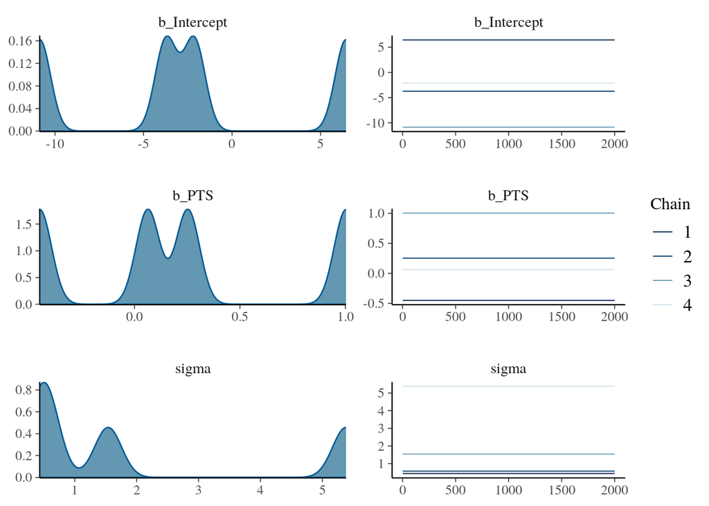

```r
plot(regresion_bayesiana_no_warmup, ask = FALSE)
```

## Poco warm-up

¿Qué pasa con nuestro modelo si realizamos un warmup muy pequeño? En este caso, hagamos un warmup de solo 100 iteraciones

```r
regresion_bayesiana_poco_warmup <- brm(
  formula = salario ~ PTS,
  data = nba_salarios_estadisticas_partido,
  warmup = 100,
  cores = 6,
  seed = 1992
)
```

```
## Warning: Examine the pairs() plot to diagnose sampling problems
```

```
## Warning: The largest R-hat is 2.67, indicating chains have not mixed.
## Running the chains for more iterations may help. See
## https://mc-stan.org/misc/warnings.html#r-hat
```

```
## Warning: Bulk Effective Samples Size (ESS) is too low, indicating posterior means and medians may be unreliable.
## Running the chains for more iterations may help. See
## https://mc-stan.org/misc/warnings.html#bulk-ess
```

```
## Warning: Tail Effective Samples Size (ESS) is too low, indicating posterior variances and tail quantiles may be unreliable.
## Running the chains for more iterations may help. See
## https://mc-stan.org/misc/warnings.html#tail-ess
```

Nuevamente en el proceso ya nos aparecen varias advertencias indicando que el algoritmo/modelo parece haber divergido y que las medias y medianas que surgen de las distribuciones posteriores no son confiables.

Veamos el resumen del modelo:

```r
summary(regresion_bayesiana_poco_warmup)
```

```
## Warning: Parts of the model have not converged (some Rhats are > 1.05). Be
## careful when analysing the results! We recommend running more iterations and/or
## setting stronger priors.
```

```
##  Family: gaussian
##   Links: mu = identity; sigma = identity
## Formula: salario ~ PTS
##    Data: nba_salarios_estadisticas_partido (Number of observations: 409)
##   Draws: 4 chains, each with iter = 2000; warmup = 100; thin = 1;
##          total post-warmup draws = 7600
##
## Population-Level Effects:
##           Estimate Est.Error  l-95% CI u-95% CI Rhat Bulk_ESS Tail_ESS
## Intercept  -603.17   6869.93 -14843.84 10439.56 2.61        5       12
## PTS          50.16    676.02  -1111.92  1402.07 2.67        5       12
##
## Family Specific Parameters:
##          Estimate Est.Error    l-95% CI    u-95% CI Rhat Bulk_ESS Tail_ESS
## sigma 14573941.24 506612.24 13632433.45 15595419.77 1.00     7128     5259
##
## Draws were sampled using sampling(NUTS). For each parameter, Bulk_ESS
## and Tail_ESS are effective sample size measures, and Rhat is the potential
## scale reduction factor on split chains (at convergence, Rhat = 1).
```

Observando el resumen vemos que los valores de **Rhat** son grandes y superan al 1 en el caso de $\beta_0$ y $\beta_1$ mientras que para el caso de $\sigma$ el valor es igual a 1. Además, al igual que antes se observa que la media y los límites de los intervalos dan valores muy distintos a los que ya habíamos observado.

Por último, veamos los gráficos de las distribuciones a posteriori y del proceso de muestreo

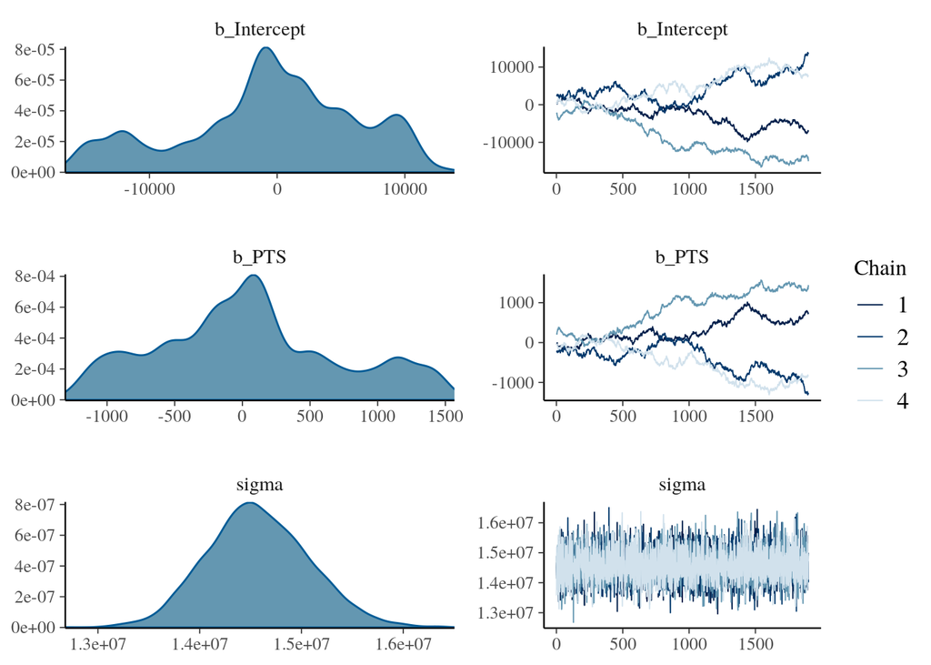

```r
plot(regresion_bayesiana_poco_warmup, ask = FALSE)
```